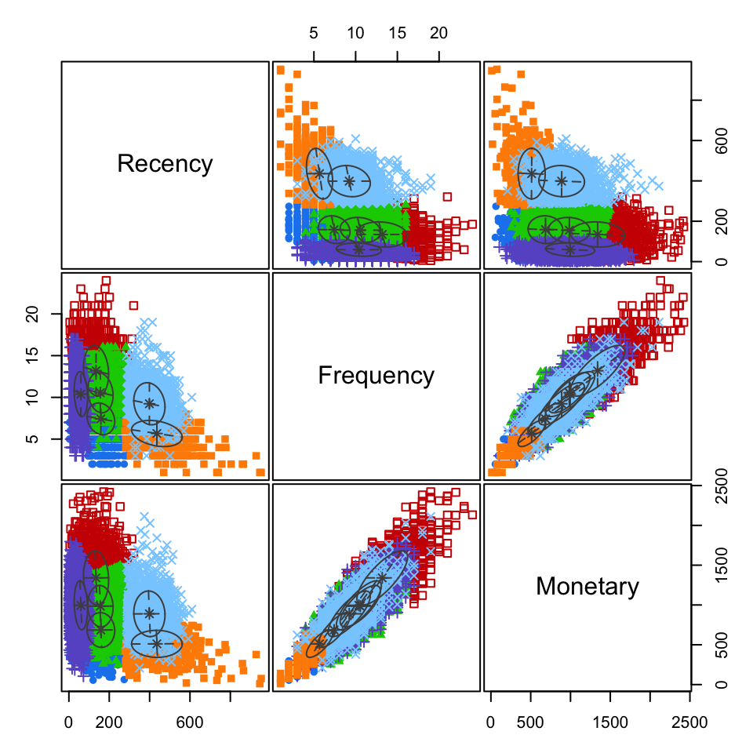

```r
plot(mix, what="classification")
```

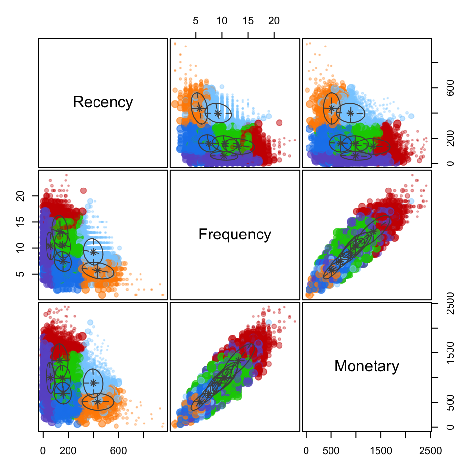

```r
plot(mix, what="uncertainty")
```

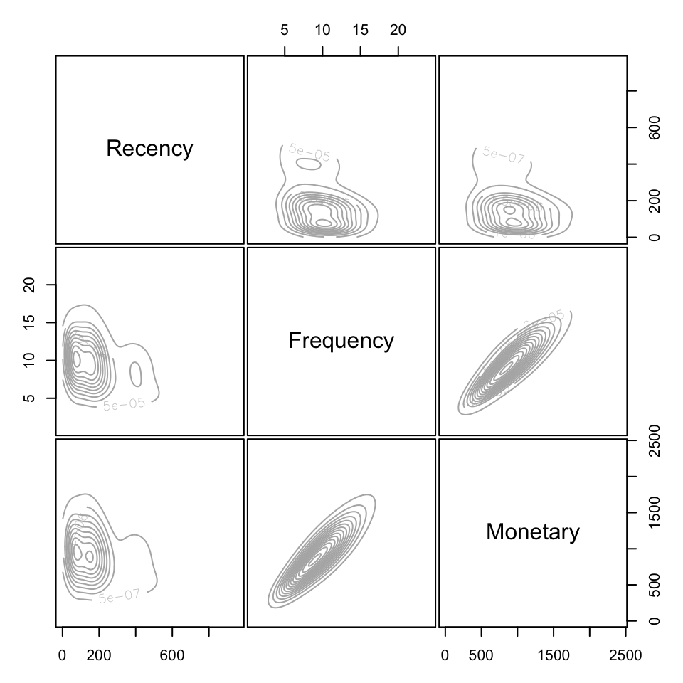

```r
plot(mix, what="density")
```

```r
#-- get parameters
summary(mix, parameters=TRUE)
```

```
#> ----------------------------------------------------
#> Gaussian finite mixture model fitted by EM algorithm
#> ----------------------------------------------------
#>
#> Mclust VVE (ellipsoidal, equal orientation) model with 6 components:
#>
#>  log-likelihood     n df       BIC       ICL
#>       -151910.2 10000 44 -304225.6 -313392.8
#>
#> Clustering table:
#>    1    2    3    4    5    6
#> 1769  772 3341 2378  550 1190
#>
#> Mixing probabilities:
#>          1          2          3          4          5          6
#> 0.19088238 0.12832983 0.31313217 0.18681861 0.05918568 0.12165132
#>
#> Means:
#>                [,1]      [,2]      [,3]      [,4]       [,5]       [,6]
#> Recency   158.48585  134.5306 155.76602  59.37000 435.967024 398.856975
#> Frequency   7.42058   13.1895  10.55646  10.38767   5.670989   9.231435
#> Monetary  685.61865 1340.3042 984.73181 995.82331 511.633763 889.005780
#>
#> Variances:
#> [,,1]
#>              Recency  Frequency   Monetary
#> Recency   4701.19072 -20.909715  -671.6703
#> Frequency  -20.90971   3.626436   327.0627
#> Monetary  -671.67030 327.062677 47584.0919
#> [,,2]
#>               Recency  Frequency    Monetary
#> Recency    3885.79361 -25.494820  -1759.7713
#> Frequency   -25.49482   9.232399    799.2757
#> Monetary  -1759.77128 799.275690 116226.2143
#> [,,3]
#>              Recency Frequency   Monetary
#> Recency   3979.70597 -20.62824  -998.2929
#> Frequency  -20.62824   5.80822   465.5482
#> Monetary  -998.29294 465.54825 67711.4353
#> [,,4]
#>               Recency  Frequency   Monetary
#> Recency    1095.64764 -13.859364 -1474.5248
#> Frequency   -13.85936   7.252261   654.9565
#> Monetary  -1474.52476 654.956459 95223.2839
#> [,,5]
#>               Recency  Frequency   Monetary
#> Recency   15749.74427 -56.109284  -205.5398
#> Frequency   -56.10928   2.454391   197.8929
#> Monetary   -205.53978 197.892872 28893.6266
#> [,,6]
#>               Recency  Frequency   Monetary
#> Recency    5976.06405 -28.905663 -1194.9610
#> Frequency   -28.90566   6.368176   565.5536
#> Monetary  -1194.96102 565.553634 82265.0171
```

```r
#-- More detailed analysis: see https://www.stat.washington.edu/sites/default/files/files/reports/2012/tr597.pdf
dataXBIC = mclustBIC(dataX)
dataXSummary  = summary(dataXBIC, data=dataX)
dataXSummary
```

[output not shown]

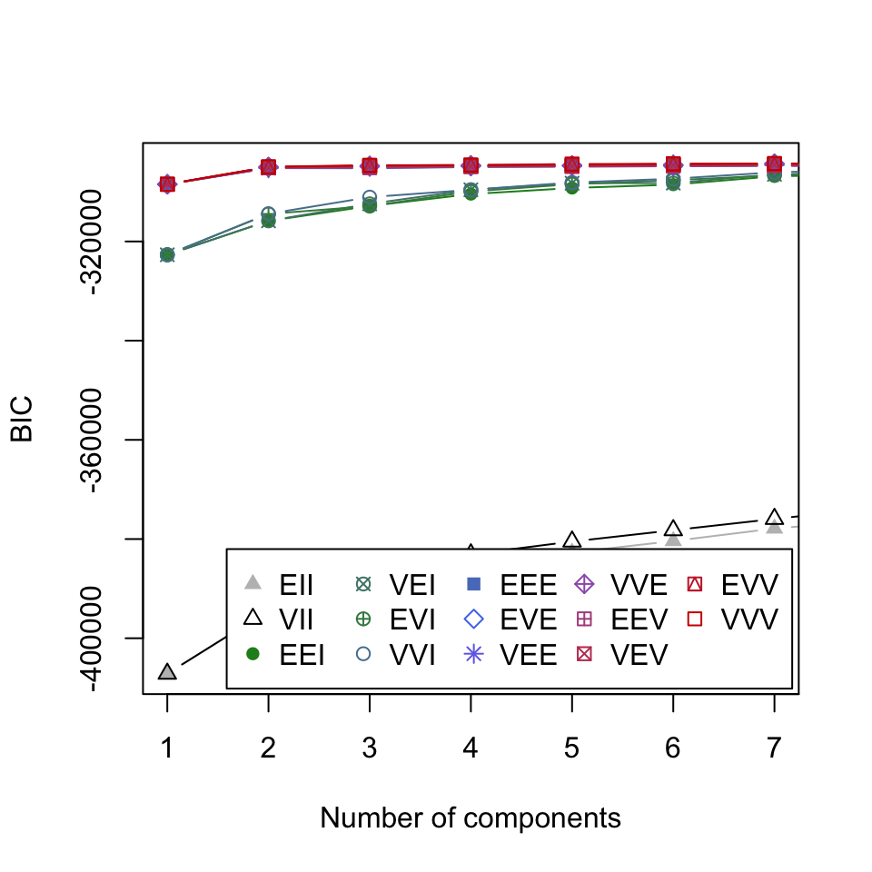

```r
plot(dataXBIC, G=1:7, legendArgs=list(x="bottomright",ncol=5)) # ,ylim=c(-2500,-2300)
```

```r
#-- tidy eval (using broom package)
library(broom) # for augment(), tidy(), glance()

# augment() adds MAP class label and associated probability
augment(mix, dataX)
```

```
#> # A tibble: 10,000 x 5
#>    Recency Frequency Monetary .class .uncertainty
#>      <int>     <int>    <int> <fct>         <dbl>
#>  1     139        13     1147 3            0.274
#>  2     447        10      939 6            0.0145
#>  3     164         7      690 1            0.305
#>  4     120        11     1191 3            0.414
#>  5     213        13      996 3            0.187
#>  6     111         9     1005 3            0.554
#>  7     286        13     1290 3            0.541
#>  8     183         8      908 3            0.513
#>  9     264         5      519 1            0.308
#> 10     165         7      947 3            0.456
#> # … with 9,990 more rows
```

```r
# tidy() summarizes each component (but no var-cov matrix yet)
tidy(mix)
```

```
#> # A tibble: 6 x 6
#>   component  size proportion mean.Recency mean.Frequency mean.Monetary
#>       <int> <int>      <dbl>        <dbl>          <dbl>         <dbl>
#> 1         1  1769     0.191         158.            7.42          686.
#> 2         2   772     0.128         135.           13.2          1340.
#> 3         3  3341     0.313         156.           10.6           985.
#> 4         4  2378     0.187          59.4          10.4           996.
#> 5         5   550     0.0592        436.            5.67          512.
#> 6         6  1190     0.122         399.            9.23          889.
```

```r
# glance() summarizes the best model
glance(mix)
```

```
#> # A tibble: 1 x 7
#>   model     G      BIC   logLik    df hypvol  nobs
#>   <chr> <int>    <dbl>    <dbl> <dbl>  <dbl> <int>
#> 1 VVE       6 -304226. -151910.    44     NA 10000
```

```r
mix$classification[1] == mix$classification[100]
```

```
#> [1] FALSE
```

```r
# mclustBootstrapLRT(dataX, modelName = "VVV")
# mclustBootstrapLRT(dataX, modelName = "EVE")
```

4. Discuss how you would cluster the customers if you had to do this for your job. Do you think one model would do better than the others?

### Problem 6.2: Poisson Mixture Model

The pmf of a Poisson random variable is:

$$\begin{align*} f_k(x; \lambda_k) = \frac{\lambda_k^x e^{-\lambda_k}}{x!} \end{align*}$$

A two-component Poisson mixture model can be written:

$$\begin{align*} f(x; \theta) = \pi \frac{\lambda_1^x e^{-\lambda_1}}{x!} + (1-\pi) \frac{\lambda_2^x e^{-\lambda_2}}{x!} \end{align*}$$

1. What are the parameters of the model?

$\pi$

$\lambda_1$

$\lambda_2$

2. Write down the log-likelihood for $n$ independent observations ($x_1, x_2, \ldots, x_n$).

the likelihood notation is: $L(x ; \theta)$

the log-likelihood notation is: $lnL(x ; \theta)$

$lnL(x;\theta) = \sum_{i=1}^{n} \ln \left(\pi \frac{\lambda_{1}^{x_{i}} e^{-\lambda_{1}}}{x_{i} !}+(1-\pi) \frac{\lambda_{2}^{x_{i}} e^{-\lambda_{2}}}{x_{i} !}\right)$

3. Suppose we have initial values of the parameters. Write down the equation for updating the *responsibilities*.

reference: based on the ESL page 275. Algorithm 8.1, assue we have initial valeus of the parameters: r1 and r2, following the 2rd step

$$\hat{\gamma}_{i}=\frac{\hat{\pi} \phi_{\hat{\theta}_{2}}\left(y_{i}\right)}{(1-\hat{\pi}) \phi_{\hat{\theta}_{1}}\left(y_{i}\right)+\hat{\pi} \phi_{\hat{\theta}_{2}}\left(y_{i}\right)}$$

$${r}_{1}=\frac{\hat{\pi} \phi_{\hat{\theta}_{2}}\left(y_{i}\right)}{(1-\hat{\pi}) \phi_{\hat{\theta}_{1}}\left(y_{i}\right)+\hat{\pi} \phi_{\hat{\theta}_{2}}\left(y_{i}\right)}$$

$${r}_{2}=\frac{\hat{\pi} \phi_{\hat{\theta}_{3}}\left(y_{i}\right)}{(1-\hat{\pi}) \phi_{\hat{\theta}_{2}}\left(y_{i}\right)+\hat{\pi} \phi_{\hat{\theta}_{3}}\left(y_{i}\right)}$$

4. Suppose we have responsibilities, $r_{ik}$ for all $i=1, 2, \ldots, n$ and $k=1,2$. Write down the equations for updating the parameters.

$${\lambda_1}=\frac{\sum_{i=1}^{N}\left(1-\hat{\gamma}_{i}\right) y_{i}}{\sum_{i=1}^{N}\left(1-\hat{\gamma}_{i}\right)}$$

$${\lambda_2}=\frac{\sum_{i=1}^{n} r_{i} y_{i}}{\sum_{i=1}^{n}}$$
$$\hat{\pi}=\sum_{i=1}^{N} \hat{\gamma}_{i} / N$$

5. Fit a two-component Poisson mixture model, report the estimated parameter values, and show a plot of the estimated mixture pmf for the following data:

```r
#-- Run this code to generate the data
set.seed(123)             # set seed for reproducibility
n = 200                   # sample size
z = sample(1:2, size=n, replace=TRUE, prob=c(.25, .75)) # sample the latent class
theta = c(8, 16)          # true parameters
y = ifelse(z==1, rpois(n, lambda=theta[1]), rpois(n, lambda=theta[2]))
```

Note: The function `poisregmixEM()` in the R package `mixtools` is designed to estimate a mixture of *Poisson regression* models. We can still use this function for our problem of density estimation if it is recast as an intercept-only regression. To do so, set the $x$ argument (predictors) to `x = rep(1, length(y))` and `addintercept = FALSE`.

Look carefully at the output from this model. The `beta` values (regression coefficients) are on the log scale.

```r
x = rep(1,length(y))

model_e =  poisregmixEM(x=x,y=y, addintercept = FALSE)
```

```
#> number of iterations= 46
```

```r
summary(model_e)
```

```
#> summary of poisregmixEM object:
#>          comp 1   comp 2
#> lambda 0.728314 0.271686
#> beta1  2.781594 2.064644
#> loglik at estimate:  -611.2228
```

```r
model_e$lambda
```

```
#> [1] 0.7283145 0.2716855
```

```r
# since the beta of this model is in log scale, in order to reverse it, we need to take e^beta
new_betas = exp(model_e$beta)  # 16.14473, 7.882481
```

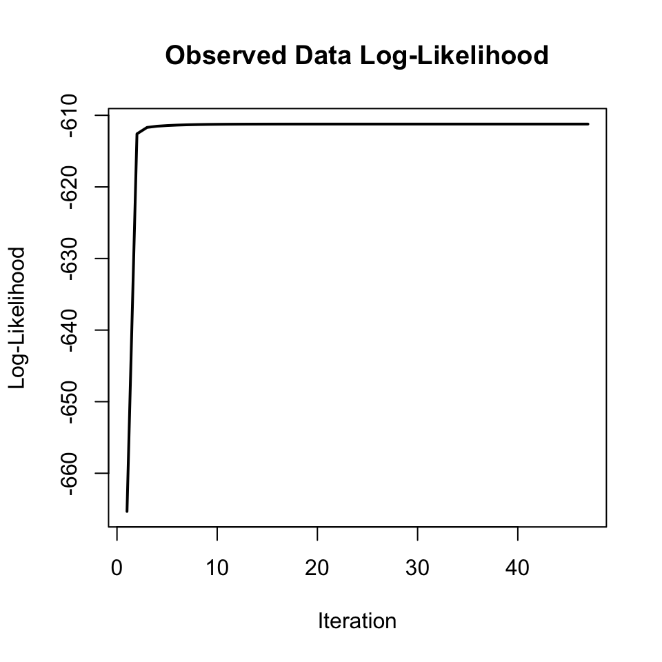

```r
beta_total = c(7.88,16.14)
plot(model_e)
```

6. **2 pts Extra Credit**: Write a function that estimates this two-component mixture model using the EM approach. Show that it gives the same result as part *e*.
   - Note: you are not permitted to copy code. Write everything from scratch and use comments to indicate how the code works (e.g., the E-step, M-step, initialization strategy, and convergence should be clear).
   - Cite any resources you consulted to help with the coding.